# miMeta Tutorial for SMESH

Zhoujingpeng Wei

Department of Biostatistics and Medical Informatics, University of Wisconsin-Madison

zwei74@wisc.edu

2026-10-21

#### Package

miMeta 2.1.0

# 1 Introduction

A conventional fixed-effect meta-analysis summarizes each microbial feature through one overall association. When microbial association profiles differ across contexts (e.g., disease stages), this approach does not reveal latent groups of contexts and may attenuate or obscure context-dependent signals. SMESH [1] addresses this problem by learning context clusters and sparse cluster-level association patterns from effect estimates and standard errors.

SMESH groups the **contexts** of a study collection into a small number of latent **clusters** and estimates the microbial features associated with a covariate of interest in each cluster. The result separates

- the **all-cluster-shared** signatures, selected as associated in every cluster in which they are estimable, although their effect magnitudes and directions may differ across clusters, from
- the **context-dependent** signatures, selected in only a subset of clusters.

A context is whatever the clusters are meant to be learned over: a disease, a tumor type, a disease stage. Studies assigned to the same context are first combined into one context-level estimate and standard error. Each context therefore contributes one association profile to the clustering, while evidence from multiple studies is reflected through increased precision.

The package exposes SMESH through two functions:

- **`smesh`** runs everything from sequencing read counts. It generates study-level association estimates and standard errors with PALM [2], combines the studies of each context by fixed-effect meta-analysis, and fits the SMESH model.
- **`smesh.summary`** fits the SMESH model to context-level summary statistics you supply. Use it when the studies cannot be shared centrally, or when you would rather use alternative summary statistics.

# 2 Installation

Install package from GitHub.

```r
if(!require("miMeta", quietly = TRUE)){
  devtools::install_github("ZjpWei/miMeta")
}
## `smesh` generates its summary statistics with PALM, which is installed the same way.
if(!require("PALM", quietly = TRUE)){
  devtools::install_github("ZjpWei/PALM_package")
}
```

Load the packages.

```r
library("miMeta")
library("PALM")
```

# 3 Data processing

We use `sim_data`, a small simulated data set shipped with the package, to demonstrate the use of each function. Because the data are simulated, the true clusters and signatures are known, and the fit can be checked against them. `sim_data` holds

- “sim_abd”: a list of sample-by-feature matrices of sequencing read counts, one per context. Each of the 10 contexts has 100 samples (50 controls and 50 cases) and 100 microbial features.
- “sim_meta”: the sample-level variables, “Sample_ID”, “Context” and “Group”, the disease status (1 for a case, 0 for a control).
- “sim_truth”: the truth the data were simulated from. The 10 contexts fall into two latent clusters of five, and 30 of the 100 features are true signatures: 15 all-cluster shared, 8 specific to cluster C1 and 7 specific to cluster C2.

The counts were simulated with MIDASim [3] from 10 colorectal neoplasia metagenomic studies, following the simulation design of the SMESH paper [1]. The disease status is the covariate of interest.

```r
data("sim_data")

## Sequencing read counts, one sample-by-feature matrix per context
feature.counts <- sim_data$sim_abd
sim_meta <- sim_data$sim_meta
sapply(feature.counts, dim)
```

```
##      Context01 Context02 Context03 Context04 Context05 Context06 Context07
## [1,]       100       100       100       100       100       100       100
## [2,]       100       100       100       100       100       100       100
##      Context08 Context09 Context10
## [1,]       100       100       100
## [2,]       100       100       100
```

```r
## Covariate of interest: disease status, one single-column matrix per context
covariate.interest <- lapply(names(feature.counts), function(d) {
  m <- sim_meta[sim_meta$Context == d, ]
  matrix(m$Group, ncol = 1, dimnames = list(m$Sample_ID, "disease"))
})
names(covariate.interest) <- names(feature.counts)
```

# 4 Structure-learning meta-analysis given all samples of all participating studies

There are two approaches miMeta can run SMESH.

Approach #1: If the individual-level sample data across all participating studies are available, the function `smesh` can take these data as input to generate summary association statistics for each study, combine the studies of each context into context-level summary statistics, and learn the context clusters together with the all-cluster-shared and context-dependent signatures.

Approach #2: If individual-level samples of each study are not in a central place, summary statistics can be generated for each study separately using the functions `palm.null.model` and `palm.get.summary` in the PALM package, and combined into context-level summary statistics using the function `palm.meta.summary`. The context-level summary statistics can be transported to a central place to learn the context clusters and signatures using the function `smesh.summary`.

We demonstrate Approach #1 in this section and Approach #2 in the next section.

Each simulated context is a single study, so `context` is left at `NULL`. When several studies address the same context, `context` maps each study to its context, and `smesh` combines the studies of a context before the clusters are learned. `covariate.adjust` and `cluster` pass covariates to adjust for and the subject identity of repeated measures to PALM; the simulated data have neither. With the default `G = NULL`, the number of clusters is selected by the minimum GIC.

```r
smesh.result <- smesh(feature.counts = feature.counts,
                      covariate.interest = covariate.interest,
                      verbose = TRUE)
```

The result is a list with one element per covariate of interest. Ours is named `disease`.

```r
smesh.model <- smesh.result$disease
names(smesh.model)
```

```
## [1] "effects"              "context_assignments"  "posterior_membership"
## [4] "mixing_proportions"   "gic"                  "diagnostics"
```

- `effects` is the feature-by-cluster matrix of final association effect estimates, from the post-selection refit. A feature with a nonzero entry in at least one cluster is a selected signature; `NA` marks a cluster in which no context could estimate the feature.
- `context_assignments` gives the cluster each context is assigned to.
- `posterior_membership` and `mixing_proportions` describe the fitted mixture.
- `gic` is the generalized information criterion of the fit.
- `diagnostics` holds computational diagnostics, described under *Interpreting and checking the fit* below.

## 4.1 Which contexts cluster together

```r
smesh.model$context_assignments
```

```
##      context cluster posterior_probability
## 1  Context01      C1                     1
## 2  Context02      C1                     1
## 3  Context03      C1                     1
## 4  Context04      C1                     1
## 5  Context05      C1                     1
## 6  Context06      C2                     1
## 7  Context07      C2                     1
## 8  Context08      C2                     1
## 9  Context09      C2                     1
## 10 Context10      C2                     1
```

Cluster labels are arbitrary, so the learned clusters are compared with the true clusters by cross-tabulating the contexts:

```r
table(learned = smesh.model$context_assignments$cluster,
      truth   = sim_data$sim_truth$cluster[smesh.model$context_assignments$context])
```

```
##        truth
## learned C1 C2
##      C1  5  0
##      C2  0  5
```

## 4.2 Which features are selected, and where

The signatures split into those selected in every cluster in which they are estimable and those selected in only some of them. This is the distinction SMESH exists to make. `signature_table()` lists them, one row per signature, with its sharing category, the clusters in which it is selected, and its final effect in each cluster:

```r
sig <- signature_table(smesh.result)
head(sig)
```

```
##       feature            sharing active_clusters  effect_C1  effect_C2
## 1 feature_042 all-cluster shared           C1|C2 -0.7688178 -0.7688178
## 2 feature_056 all-cluster shared           C1|C2 -0.7604122 -0.7604122
## 3 feature_079 all-cluster shared           C1|C2 -0.7000921 -0.7000921
## 4 feature_048 all-cluster shared           C1|C2 -0.6926668 -0.6926668
## 5 feature_054 all-cluster shared           C1|C2 -0.5606143 -0.5606143
## 6 feature_099 all-cluster shared           C1|C2  0.3791798  0.7787391
##   estimable_C1 estimable_C2
## 1         TRUE         TRUE
## 2         TRUE         TRUE
## 3         TRUE         TRUE
## 4         TRUE         TRUE
## 5         TRUE         TRUE
## 6         TRUE         TRUE
```

```r
table(sig$sharing)
```

```
##
## all-cluster shared   cluster-specific
##                 15                 15
```

`plot_signatures()` draws the same table as a heat map, the tutorial counterpart of panel A of the paper’s real-data figures: one column per cluster, one row per signature, grouped by sharing category.

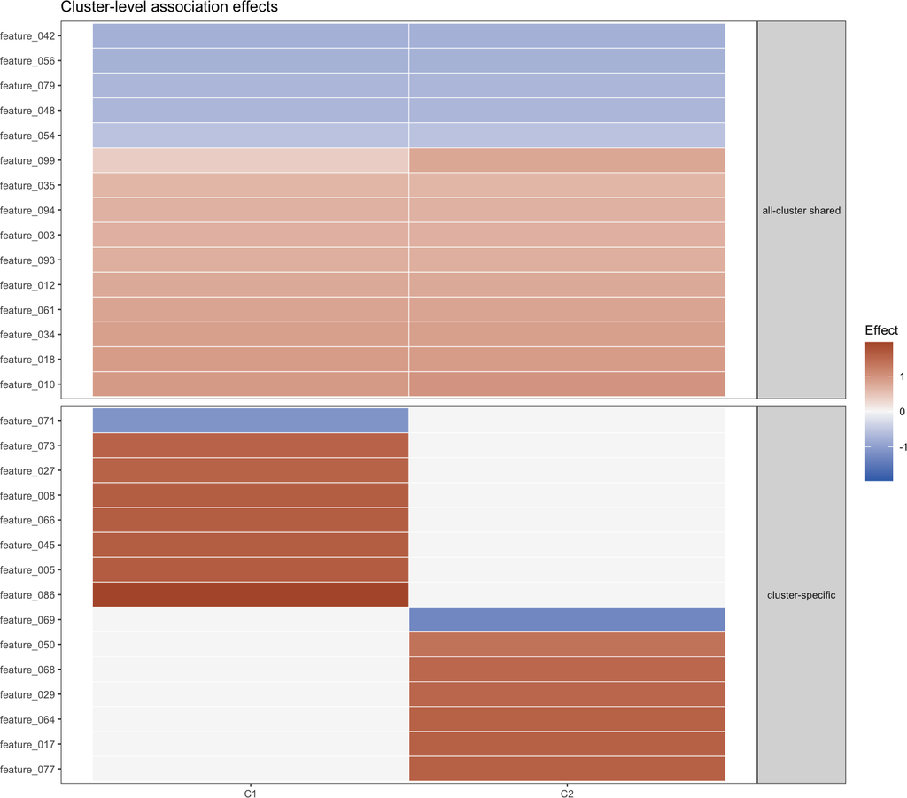

```r
plot_signatures(smesh.result)
```

Features in the all-cluster-shared block are selected as associated in every cluster in which they are estimable; their effect magnitudes and directions may differ across clusters. Features in the other blocks are selected in only a subset of clusters; pooling across all contexts may attenuate, cancel, or obscure these heterogeneous effects.

The selected signatures can be checked against the true ones. Each true signature is listed with the clusters in which SMESH selected it, and “not selected” marks a true signature that was missed:

```r
truth <- sim_data$sim_truth$signatures
table(truth    = truth$sharing,
      selected = ifelse(truth$feature %in% sig$feature,
                        sig$active_clusters[match(truth$feature, sig$feature)],
                        "not selected"))
```

```
##                     selected
## truth                C1 C1|C2 C2
##   all-cluster shared  0    15  0
##   C1-specific         8     0  0
##   C2-specific         0     0  7
```

```r
## Selected features that are not true signatures
setdiff(sig$feature, truth$feature)
```

```
## character(0)
```

# 5 Structure-learning meta-analysis given summary statistics

If the individual-level samples cannot be brought to one place, or if you would rather use alternative summary statistics, run SMESH in two steps. The two steps below repeat what `smesh` does internally in the previous section.

## 5.1 Step 1: generate the summary statistics and aggregate them to context level

If the data of different studies live in different locations and cannot be conveniently shared among studies, we can first generate summary statistics for each study and combine the studies of each context into a single context-level estimate and standard error.

```r
# One summary statistic per study, with the same inputs smesh() used above
null.obj <- PALM::palm.null.model(feature.counts = feature.counts,
                                  prev.filter = 0.1)

# correct = "tune" is smesh()'s default; PALM's own default is "median"
study.stats <- PALM::palm.get.summary(null.obj = null.obj,
                                      covariate.interest = covariate.interest,
                                      correct = "tune")

# Each simulated context is a single study, so the per-study summaries are
# already the context-level summaries
context.stats <- study.stats
str(context.stats[[1]], max.level = 1)
```

```
## List of 3
##  $ est   : num [1:100, 1] -0.256 -0.484 0.64 -0.104 1.769 ...
##   ..- attr(*, "dimnames")=List of 2
##  $ stderr: num [1:100, 1] 0.386 0.309 0.214 0.512 0.232 ...
##   ..- attr(*, "dimnames")=List of 2
##  $ n     : int 100
```

When several studies address the same context, combine them by fixed-effect meta-analysis with `palm.meta.summary`, which is what `smesh` does when `context` is supplied. With `min.context`, `smesh` further keeps only the features estimable in at least that many contexts. The chunk below shows both steps; it is not run here, because the simulated data have one study per context.

```r
# `context` maps study identifiers to context labels, for example
# context <- c(study_A = "CRC", study_B = "CRC", study_C = "IBD")

# (a) Combine the studies of each context by fixed-effect meta-analysis
context.stats <- list()
for(ctx in unique(context)){
  keep <- names(study.stats)[context[names(study.stats)] == ctx]
  res <- PALM::palm.meta.summary(summary.stats = study.stats[keep])

  feature.ID <- Reduce(union, lapply(res, function(x) x$feature))
  est.mat <- se.mat <- matrix(NA_real_, length(feature.ID), length(res),
                              dimnames = list(feature.ID, names(res)))
  for(cov.int in names(res)){
    est.mat[res[[cov.int]]$feature, cov.int] <- res[[cov.int]]$coef
    se.mat[res[[cov.int]]$feature, cov.int]  <- res[[cov.int]]$stderr
  }
  context.stats[[ctx]] <- list(est = est.mat, stderr = se.mat,
                               n = sum(sapply(study.stats[keep], function(d) d$n)))
}

# (b) Keep the features estimable in at least `min.context` contexts
min.context <- 2
n.context <- table(unlist(lapply(context.stats, function(d)
  rownames(d$est)[rowSums(!is.na(d$est)) > 0])))
keep.ID <- names(n.context)[n.context >= min.context]
context.stats <- lapply(context.stats, function(d) {
  id <- intersect(keep.ID, rownames(d$est))
  d$est    <- d$est[id, , drop = FALSE]
  d$stderr <- d$stderr[id, , drop = FALSE]
  d
})
```

**Customizing the summary statistics.** `smesh.summary` only requires that each element of the list is one context, named by context label, holding

- `est` — a feature-by-covariate matrix of association coefficient estimates,
- `stderr` — the matching matrix of standard errors, and
- `n` — the number of samples behind the context,

with `NA` wherever a context could not estimate a feature. Feature identifiers must be harmonized, so that the same identifier denotes the same microbial feature in every context. Alternative summary statistics from any association model that yields a coefficient and a standard error per feature can fill those matrices; only the way `est` and `stderr` are produced changes, and the rest of this section is unaffected.

## 5.2 Step 2: run the structure-learning meta-analysis

```r
smesh.result.2 <- smesh.summary(summary.stats = context.stats, verbose = TRUE)
smesh.model.2 <- smesh.result.2$disease
```

The clusters and the signatures agree with those from `smesh` in the previous section, as they should — Step 1 produces the same context-level summary statistics that `smesh` builds internally, and both routes then use the same estimator.

```r
smesh.model.2$context_assignments
```

```
##      context cluster posterior_probability
## 1  Context01      C1                     1
## 2  Context02      C1                     1
## 3  Context03      C1                     1
## 4  Context04      C1                     1
## 5  Context05      C1                     1
## 6  Context06      C2                     1
## 7  Context07      C2                     1
## 8  Context08      C2                     1
## 9  Context09      C2                     1
## 10 Context10      C2                     1
```

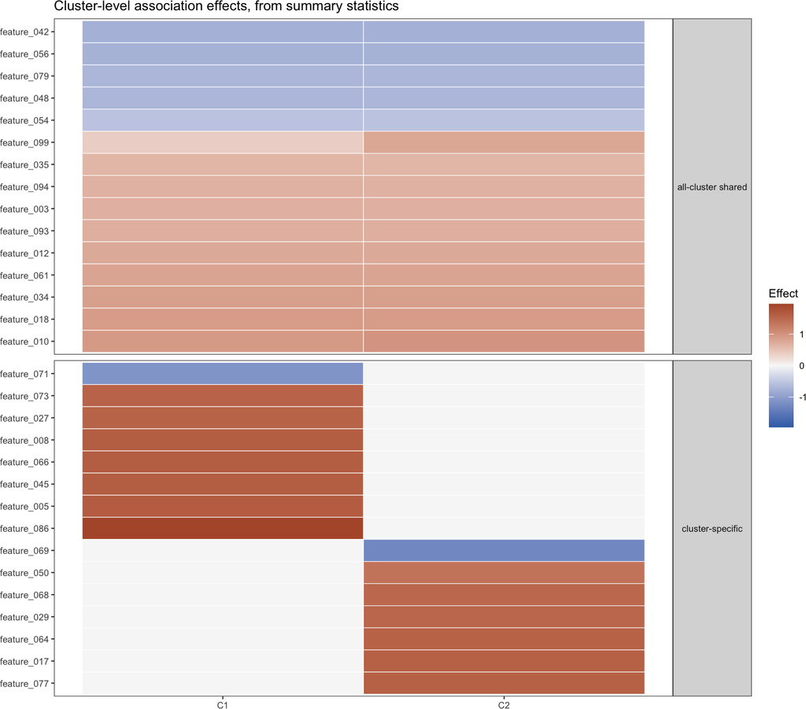

```r
plot_signatures(smesh.result.2, title = "Cluster-level association effects, from summary statistics")
```

A direct comparison of the two routes:

```r
data.frame(
  route      = c("smesh", "smesh.summary"),
  contexts   = c(nrow(smesh.model$context_assignments), nrow(smesh.model.2$context_assignments)),
  clusters   = c(ncol(smesh.model$effects), ncol(smesh.model.2$effects)),
  signatures = c(nrow(signature_table(smesh.result)), nrow(signature_table(smesh.result.2))),
  gic        = round(c(smesh.model$gic, smesh.model.2$gic), 4)
)
```

```
##           route contexts clusters signatures    gic
## 1         smesh       10        2         30 0.9157
## 2 smesh.summary       10        2         30 0.9157
```

# 6 Interpreting and checking the fit

## 6.1 Selected number of clusters

With `G = NULL`, the number of clusters is chosen by the minimum generalized information criterion (GIC): every candidate `G` from 1 to `round(2L/3)`, for `L` contexts, is fitted, and the one with the smallest GIC is kept. The search path shows the GIC at each candidate `G` and which one was selected; `gic` is the GIC of the reported model.

```r
smesh.model$diagnostics$gic_path
```

```
##   G       gic selected
## 1 1 1.6720653    FALSE
## 2 2 0.9157447     TRUE
## 3 3 0.9226525    FALSE
## 4 4 0.9239839    FALSE
## 5 5 0.9353283    FALSE
## 6 6 0.9377995    FALSE
## 7 7 0.9447072    FALSE
```

```r
smesh.model$gic
```

```
## [1] 0.9157447
```

## 6.2 Posterior cluster membership

`context_assignments` gives the cluster of each context and the posterior probability of that cluster under the fitted mixture; `posterior_membership` gives the full context-by-cluster matrix. A probability well below one marks a context whose assignment is uncertain.

```r
round(smesh.model$posterior_membership, 3)
```

```
##           C1 C2
## Context01  1  0
## Context02  1  0
## Context03  1  0
## Context04  1  0
## Context05  1  0
## Context06  0  1
## Context07  0  1
## Context08  0  1
## Context09  0  1
## Context10  0  1
```

## 6.3 Computational check

SMESH uses multiple random starts to reduce sensitivity to local optima; `nstart` sets how many (20 by default). At each candidate number of clusters and support size, the reported fit is the converged start with the smallest GIC. The diagnostics record how many starts converged and which one was retained. They describe the optimization on these data and should not be interpreted as robustness to changes in the observed data.

```r
c(
  converged_starts =
    sum(smesh.model$diagnostics$restart_convergence),
  total_starts =
    length(smesh.model$diagnostics$restart_convergence),
  selected_restart =
    smesh.model$diagnostics$selected_restart
)
```

```
## converged_starts     total_starts selected_restart
##               20               20                1
```

# 8 Reference

1. Wei Z, Chen G, Tang ZZ. Structure-learning meta-analysis resolves cross-context heterogeneity in microbiome associations. Submitted.
2. Wei Z, Hong Q, Chen G, Hartert TV, Rosas-Salazar C, Das SR, Shilts MH, Levin AM, Tang ZZ. Fast and reliable association discovery in large-scale microbiome studies and meta-analyses using PALM. bioRxiv. 2026. doi:10.64898/2026.04.09.717497.
3. He M, Zhao N, Satten GA. MIDASim: a fast and simple simulator for realistic microbiome data. Microbiome. 2024;12:135. doi:10.1186/s40168-024-01822-z.